# Laboratorio 8-MD

Leislie R. Manjarrez O.

2023-02-22

LABORATORIO 8 - RELACIONAMIENTO “CASO HIPOTETICO”

Objetivo: Estimar el relacionamiento (relatedness, proximidad, metrica de distancia entre productos) En este ejercicio vamos a: 1. Cargar nuestra matriz hipotetica de datos 2. Calcular co ocurrencias entre personas y productos 3. Estimar el relacionamiento, teniendo como input las co-ocurrencias 4. Graficar

1.Como se mide la proximidad (relatedness) para crear el espacio producto Material: Balland, P.A. (2017) Economic Geography in R: Introduction to the EconGeo Package, Papers in Evolutionary Economic Geography, 17 (09): 1-75 Para instalar: https://www.paballand.com/install-r

Una vez instalado EconGeo llamar su libreria

```r
library (EconGeo)
```

```
##  Balland, P.A. (2017) Economic Geography in R: Introduction to the EconGeo Package, Papers in Evolutionary Economic Geography, 17 (09): 1-75
```

Llamamos a la matriz M que se encuentra en el link escrito y al ser un archivo cvs decimos que esta separado por comas, la fila inicial va a tener los titulos (header, T) y en la primer columna voy a estrablecer el nombre de mis variables

```r
M = as.matrix(
  read.csv("https://raw.githubusercontent.com/PABalland/ON/master/amz.csv" ,
           sep = ",",
           header = T,
           row.names = 1))
```

Llamo a la matriz

```r
M
```

```
##        Tie Book Surfboard Short Water
## Pierre   0    0         1     1     1
## Ron      1    1         0     0     1
## Andrea   1    1         0     0     1
## David    0    0         1     1     1
## Cesar    1    1         0     0     1
## Paula    1    1         1     1     1
```

Co-ocurrencia entre personas/paises/estados

```r
co.occurrence (M)
```

```
##        Pierre Ron Andrea David Cesar Paula
## Pierre      0   1      1     3     1     3
## Ron         1   0      3     1     3     3
## Andrea      1   3      0     1     3     3
## David       3   1      1     0     1     3
## Cesar       1   3      3     1     0     3
## Paula       3   3      3     3     3     0
```

Co-ocurrencia entre productos t es transpuesta

```r
c = co.occurrence (t(M))
```

Llamo a la matriz

```r
c
```

```
##           Tie Book Surfboard Short Water
## Tie         0    4         1     1     4
## Book        4    0         1     1     4
## Surfboard   1    1         0     3     3
## Short       1    1         3     0     3
## Water       4    4         3     3     0
```

Estima el relacionamiento o proximidad pero normalizado, para asegurar que el numero de co ocurrencias que observamos. Es mayor al numero de co ocurrencias probables (probailidad condicional) tie and s puede que no esten tan relacionados, abajo de 1 no es relacionado mientras que mayor a 1 si es relacionado

```r
r = relatedness(c)
```

Llamo a la matriz

```r
r
```

```
##                 Tie      Book Surfboard     Short    Water
## Tie       0.0000000 1.6000000 0.5121951 0.5121951 1.082707
## Book      1.6000000 0.0000000 0.5121951 0.5121951 1.082707
## Surfboard 0.5121951 0.5121951 0.0000000 1.9687500 1.038462
## Short     0.5121951 0.5121951 1.9687500 0.0000000 1.038462
## Water     1.0827068 1.0827068 1.0384615 1.0384615 0.000000
```

Para ver el algoritmo solo ejecutar relatedness. Ejecutar la regla: si el relacionamiento es menor a 1 = 0 (no habra arista que ligue producto) y si es mayor a 1 = 1 (si habra arista que ligue producto)

```r
r[r<1] = 0
r[r>1] = 1
```

Cargar libreria para graficar el espacio-producto

```r
library (igraph)
```

Comando para realizar el grafico 1

```r
g1 = graph_from_adjacency_matrix(r, mode = "undirected")
```

Para ver el gráfico

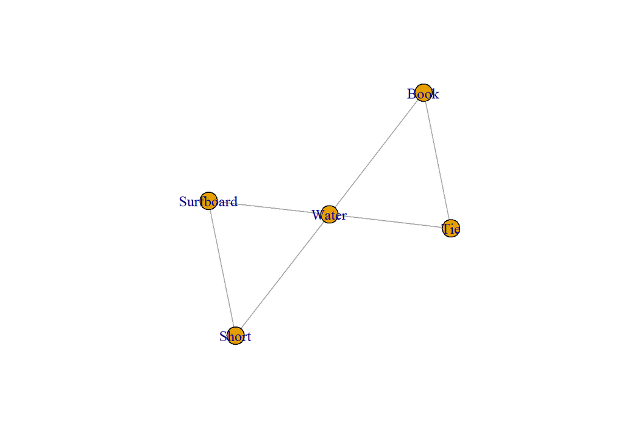

```r
plot(g1)
```